# Asteroid Classification

**Cem Sinan Ozturk**

*October 6, 2020*

In this project, I am going to perform a prediction analysis for classifying hazardous asteroids.

```python
import pandas as pd
import numpy as np
from IPython.display import display #to display all columns

import seaborn as sns
import matplotlib.pyplot as plt

import datetime
import time

from sklearn.metrics import accuracy_score, precision_recall_curve, plot_precision_recall_curve
from sklearn.metrics import roc_auc_score, precision_score, recall_score, average_precision_score
from sklearn.metrics import f1_score, plot_confusion_matrix
from sklearn.metrics import classification_report
from sklearn.metrics import plot_roc_curve

from sklearn.feature_selection import SelectFromModel

from sklearn.pipeline import Pipeline
from sklearn.model_selection import GridSearchCV, cross_val_score
from sklearn.model_selection import train_test_split

from sklearn.preprocessing import StandardScaler, OneHotEncoder
from sklearn.compose import ColumnTransformer
from sklearn.impute import SimpleImputer
from sklearn.dummy import DummyClassifier

# Models:
from sklearn.linear_model import LogisticRegression
from sklearn.neighbors import KNeighborsClassifier
from sklearn.svm import SVC
from sklearn.tree import DecisionTreeClassifier
from sklearn.ensemble import AdaBoostClassifier, GradientBoostingClassifier, RandomForestClassifier
from lightgbm import LGBMClassifier
from xgboost import XGBClassifier
```

```python
import warnings
#warnings.simplefilter(action='ignore', category=FutureWarning)
warnings.filterwarnings('ignore')
```

## EDA (Exploratory Data Analysis):

Clean the data:

- Drop perfectly correlated columns(expect one of them)
- Columns with single values
- Close Approach Date vs Epoch Date Close Approach : Same information in a different representation. Drop one of them.

This data doesn't have `null` values but it is always better to make sure.

```python
df = pd.read_csv('../data/nasa.csv')
```

```python
df.shape
```

```
(4687, 40)
```

```python
pd.set_option('display.max_columns', None)
```

```python
df.head()
```

|  | Neo Reference ID | Name | Absolute Magnitude | Est Dia in KM(min) | Est Dia in KM(max) | Est Dia in M(min) | Est Dia in M(max) | Est Dia in Miles(min) | Est Dia in Miles(max) | Est Dia in Feet(min) | Est Dia in Feet(max) | Close Approach Date | Epoch Date Close Approach | Relative Velocity km per sec | Relative Velocity km per hr | Miles per hour | Miss Dist.(Astronomical) | Miss Dist.(lunar) | Miss Dist.(kilometers) | Miss Dist.(miles) | Orbiting Body | Orbit ID | Orbit Determination Date | Orbit Uncertainity | Minimum Orbit Intersection | Jupiter Tisserand Invariant | Epoch Osculation | Eccentricity | Semi Major Axis | … |
| --- | --- | --- | --- | --- | --- | --- | --- | --- | --- | --- | --- | --- | --- | --- | --- | --- | --- | --- | --- | --- | --- | --- | --- | --- | --- | --- | --- | --- | --- | --- |
| 0 | 3703080 | 3703080 | 21.6 | 0.127220 | 0.284472 | 127.219879 | 284.472297 | 0.079051 | 0.176763 | 417.388066 | 933.308089 | 1995-01-01 | 788947200000 | 6.115834 | 22017.003799 | 13680.509944 | 0.419483 | 163.178711 | 62753692.0 | 38993336.0 | Earth | 17 | 2017-04-06 08:36:37 | 5 | 0.025282 | 4.634 | 2458000.5 | 0.425549 | 1.407011 | … |
| 1 | 3723955 | 3723955 | 21.3 | 0.146068 | 0.326618 | 146.067964 | 326.617897 | 0.090762 | 0.202951 | 479.225620 | 1071.581063 | 1995-01-01 | 788947200000 | 18.113985 | 65210.346095 | 40519.173105 | 0.383014 | 148.992630 | 57298148.0 | 35603420.0 | Earth | 21 | 2017-04-06 08:32:49 | 3 | 0.186935 | 5.457 | 2458000.5 | 0.351674 | 1.107776 | … |
| 2 | 2446862 | 2446862 | 20.3 | 0.231502 | 0.517654 | 231.502122 | 517.654482 | 0.143849 | 0.321655 | 759.521423 | 1698.341531 | 1995-01-08 | 789552000000 | 7.590711 | 27326.560182 | 16979.661798 | 0.050956 | 19.821890 | 7622911.5 | 4736657.5 | Earth | 22 | 2017-04-06 09:20:19 | 0 | 0.043058 | 4.557 | 2458000.5 | 0.348248 | 1.458824 | … |
| 3 | 3092506 | 3092506 | 27.4 | 0.008801 | 0.019681 | 8.801465 | 19.680675 | 0.005469 | 0.012229 | 28.876199 | 64.569144 | 1995-01-15 | 790156800000 | 11.173874 | 40225.948191 | 24994.839864 | 0.285322 | 110.990387 | 42683616.0 | 26522368.0 | Earth | 7 | 2017-04-06 09:15:49 | 6 | 0.005512 | 5.093 | 2458000.5 | 0.216578 | 1.255903 | … |
| 4 | 3514799 | 3514799 | 21.6 | 0.127220 | 0.284472 | 127.219879 | 284.472297 | 0.079051 | 0.176763 | 417.388066 | 933.308089 | 1995-01-15 | 790156800000 | 9.840831 | 35426.991794 | 22012.954985 | 0.407832 | 158.646713 | 61010824.0 | 37910368.0 | Earth | 25 | 2017-04-06 08:57:58 | 1 | 0.034798 | 5.154 | 2458000.5 | 0.210448 | 1.225615 | … |

```python
df.info()
```

```
<class 'pandas.core.frame.DataFrame'>
RangeIndex: 4687 entries, 0 to 4686
Data columns (total 40 columns):
 #   Column                        Non-Null Count  Dtype
---  ------                        --------------  -----
 0   Neo Reference ID              4687 non-null   int64
 1   Name                          4687 non-null   int64
 2   Absolute Magnitude            4687 non-null   float64
 3   Est Dia in KM(min)            4687 non-null   float64
 4   Est Dia in KM(max)            4687 non-null   float64
 5   Est Dia in M(min)             4687 non-null   float64
 6   Est Dia in M(max)             4687 non-null   float64
 7   Est Dia in Miles(min)         4687 non-null   float64
 8   Est Dia in Miles(max)         4687 non-null   float64
 9   Est Dia in Feet(min)          4687 non-null   float64
```

[output cut: 32 more lines]

```python
df.describe()
```

|  | Neo Reference ID | Name | Absolute Magnitude | Est Dia in KM(min) | Est Dia in KM(max) | Est Dia in M(min) | Est Dia in M(max) | Est Dia in Miles(min) | Est Dia in Miles(max) | Est Dia in Feet(min) | Est Dia in Feet(max) | Epoch Date Close Approach | Relative Velocity km per sec | Relative Velocity km per hr | Miles per hour | Miss Dist.(Astronomical) | Miss Dist.(lunar) | Miss Dist.(kilometers) | Miss Dist.(miles) | Orbit ID | Orbit Uncertainity | Minimum Orbit Intersection | Jupiter Tisserand Invariant | Epoch Osculation | Eccentricity | Semi Major Axis | Inclination | Asc Node Longitude | Orbital Period | … |
| --- | --- | --- | --- | --- | --- | --- | --- | --- | --- | --- | --- | --- | --- | --- | --- | --- | --- | --- | --- | --- | --- | --- | --- | --- | --- | --- | --- | --- | --- | --- |
| count | 4.687000e+03 | 4.687000e+03 | 4687.000000 | 4687.000000 | 4687.000000 | 4687.000000 | 4687.000000 | 4687.000000 | 4687.000000 | 4687.000000 | 4687.000000 | 4.687000e+03 | 4687.000000 | 4687.000000 | 4687.000000 | 4687.000000 | 4687.000000 | 4.687000e+03 | 4.687000e+03 | 4687.000000 | 4687.000000 | 4687.000000 | 4687.000000 | 4.687000e+03 | 4687.000000 | 4687.000000 | 4687.000000 | 4687.000000 | 4687.000000 | … |
| mean | 3.272298e+06 | 3.272298e+06 | 22.267865 | 0.204604 | 0.457509 | 204.604203 | 457.508906 | 0.127135 | 0.284283 | 671.273653 | 1501.013521 | 1.179881e+12 | 13.970811 | 50294.919829 | 31251.307268 | 0.256778 | 99.886706 | 3.841347e+07 | 2.386902e+07 | 28.300619 | 3.516962 | 0.082320 | 5.056111 | 2.457724e+06 | 0.382569 | 1.400264 | 13.373844 | 172.157275 | 635.582076 | … |
| std | 5.486011e+05 | 5.486011e+05 | 2.890972 | 0.369573 | 0.826391 | 369.573402 | 826.391249 | 0.229642 | 0.513496 | 1212.511199 | 2711.257465 | 1.981540e+11 | 7.293223 | 26255.601377 | 16314.209644 | 0.145798 | 56.715493 | 2.181110e+07 | 1.355279e+07 | 38.299668 | 3.078307 | 0.090300 | 1.237818 | 9.202975e+02 | 0.180444 | 0.524154 | 10.936227 | 103.276777 | 370.954727 | … |
| min | 2.000433e+06 | 2.000433e+06 | 11.160000 | 0.001011 | 0.002260 | 1.010543 | 2.259644 | 0.000628 | 0.001404 | 3.315431 | 7.413530 | 7.889472e+11 | 0.335504 | 1207.814804 | 750.489149 | 0.000178 | 0.069194 | 2.660989e+04 | 1.653462e+04 | 1.000000 | 0.000000 | 0.000002 | 2.196000 | 2.450164e+06 | 0.007522 | 0.615920 | 0.014513 | 0.001941 | 176.557161 | … |
| 25% | 3.097594e+06 | 3.097594e+06 | 20.100000 | 0.033462 | 0.074824 | 33.462237 | 74.823838 | 0.020792 | 0.046493 | 109.784247 | 245.485039 | 1.015574e+12 | 8.432865 | 30358.313370 | 18863.475327 | 0.133420 | 51.900211 | 1.995928e+07 | 1.240212e+07 | 9.000000 | 0.000000 | 0.014585 | 4.049500 | 2.458000e+06 | 0.240858 | 1.000635 | 4.962341 | 83.081208 | 365.605031 | … |
| 50% | 3.514799e+06 | 3.514799e+06 | 21.900000 | 0.110804 | 0.247765 | 110.803882 | 247.765013 | 0.068850 | 0.153954 | 363.529809 | 812.877364 | 1.203062e+12 | 12.917889 | 46504.401181 | 28896.026390 | 0.265029 | 103.096123 | 3.964771e+07 | 2.463595e+07 | 16.000000 | 3.000000 | 0.047365 | 5.071000 | 2.458000e+06 | 0.372450 | 1.240981 | 10.311836 | 172.625393 | 504.947292 | … |
| 75% | 3.690060e+06 | 3.690060e+06 | 24.500000 | 0.253837 | 0.567597 | 253.837029 | 567.596853 | 0.157727 | 0.352688 | 832.798679 | 1862.194459 | 1.355558e+12 | 18.077649 | 65079.535405 | 40437.892430 | 0.384154 | 149.435921 | 5.746863e+07 | 3.570935e+07 | 31.000000 | 6.000000 | 0.123593 | 6.019000 | 2.458000e+06 | 0.512411 | 1.678364 | 19.511681 | 255.026909 | 794.195972 | … |
| max | 3.781897e+06 | 3.781897e+06 | 32.100000 | 15.579552 | 34.836938 | 15579.552413 | 34836.938254 | 9.680682 | 21.646663 | 51114.018738 | 114294.420501 | 1.473318e+12 | 44.633747 | 160681.487851 | 99841.227826 | 0.499884 | 194.454910 | 7.478160e+07 | 4.646713e+07 | 611.000000 | 9.000000 | 0.477891 | 9.025000 | 2.458020e+06 | 0.960261 | 5.072008 | 75.406667 | 359.905890 | 4172.231343 | … |

### Correlation between Features

As we can see from the following visualization, there are a number of columns which are perfectly correlated, and for most of the cases, these columns are the different representation of the same information. Therefore, it is best to eleminate extra ones.

For example, Est Diameter is given in km, m, miles and feet. We only need one of those.

```python
corr = df.corr()
corr.style.background_gradient(cmap='coolwarm').set_precision(2)
```

|  | Neo Reference ID | Name | Absolute Magnitude | Est Dia in KM(min) | Est Dia in KM(max) | Est Dia in M(min) | Est Dia in M(max) | Est Dia in Miles(min) | Est Dia in Miles(max) | Est Dia in Feet(min) | Est Dia in Feet(max) | Epoch Date Close Approach | Relative Velocity km per sec | Relative Velocity km per hr | Miles per hour | Miss Dist.(Astronomical) | Miss Dist.(lunar) | Miss Dist.(kilometers) | Miss Dist.(miles) | Orbit ID | Orbit Uncertainity | Minimum Orbit Intersection | Jupiter Tisserand Invariant | Epoch Osculation | Eccentricity | Semi Major Axis | Inclination | Asc Node Longitude | Orbital Period | … |
| --- | --- | --- | --- | --- | --- | --- | --- | --- | --- | --- | --- | --- | --- | --- | --- | --- | --- | --- | --- | --- | --- | --- | --- | --- | --- | --- | --- | --- | --- | --- |
| Neo Reference ID | 1.00 | 1.00 | 0.60 | -0.50 | -0.50 | -0.50 | -0.50 | -0.50 | -0.50 | -0.50 | -0.50 | 0.19 | -0.17 | -0.17 | -0.17 | -0.16 | -0.16 | -0.16 | -0.16 | -0.65 | 0.61 | -0.16 | -0.00 | 0.01 | -0.13 | 0.04 | -0.18 | -0.03 | 0.04 | … |
| Name | 1.00 | 1.00 | 0.60 | -0.50 | -0.50 | -0.50 | -0.50 | -0.50 | -0.50 | -0.50 | -0.50 | 0.19 | -0.17 | -0.17 | -0.17 | -0.16 | -0.16 | -0.16 | -0.16 | -0.65 | 0.61 | -0.16 | -0.00 | 0.01 | -0.13 | 0.04 | -0.18 | -0.03 | 0.04 | … |
| Absolute Magnitude | 0.60 | 0.60 | 1.00 | -0.61 | -0.61 | -0.61 | -0.61 | -0.61 | -0.61 | -0.61 | -0.61 | 0.17 | -0.38 | -0.38 | -0.38 | -0.34 | -0.34 | -0.34 | -0.34 | -0.58 | 0.68 | -0.49 | 0.24 | -0.12 | -0.36 | -0.21 | -0.46 | -0.01 | -0.21 | … |
| Est Dia in KM(min) | -0.50 | -0.50 | -0.61 | 1.00 | 1.00 | 1.00 | 1.00 | 1.00 | 1.00 | 1.00 | 1.00 | -0.09 | 0.24 | 0.24 | 0.24 | 0.19 | 0.19 | 0.19 | 0.19 | 0.72 | -0.40 | 0.26 | -0.13 | 0.06 | 0.22 | 0.12 | 0.26 | 0.04 | 0.12 | … |
| Est Dia in KM(max) | -0.50 | -0.50 | -0.61 | 1.00 | 1.00 | 1.00 | 1.00 | 1.00 | 1.00 | 1.00 | 1.00 | -0.09 | 0.24 | 0.24 | 0.24 | 0.19 | 0.19 | 0.19 | 0.19 | 0.72 | -0.40 | 0.26 | -0.13 | 0.06 | 0.22 | 0.12 | 0.26 | 0.04 | 0.12 | … |
| Est Dia in M(min) | -0.50 | -0.50 | -0.61 | 1.00 | 1.00 | 1.00 | 1.00 | 1.00 | 1.00 | 1.00 | 1.00 | -0.09 | 0.24 | 0.24 | 0.24 | 0.19 | 0.19 | 0.19 | 0.19 | 0.72 | -0.40 | 0.26 | -0.13 | 0.06 | 0.22 | 0.12 | 0.26 | 0.04 | 0.12 | … |
| Est Dia in M(max) | -0.50 | -0.50 | -0.61 | 1.00 | 1.00 | 1.00 | 1.00 | 1.00 | 1.00 | 1.00 | 1.00 | -0.09 | 0.24 | 0.24 | 0.24 | 0.19 | 0.19 | 0.19 | 0.19 | 0.72 | -0.40 | 0.26 | -0.13 | 0.06 | 0.22 | 0.12 | 0.26 | 0.04 | 0.12 | … |
| Est Dia in Miles(min) | -0.50 | -0.50 | -0.61 | 1.00 | 1.00 | 1.00 | 1.00 | 1.00 | 1.00 | 1.00 | 1.00 | -0.09 | 0.24 | 0.24 | 0.24 | 0.19 | 0.19 | 0.19 | 0.19 | 0.72 | -0.40 | 0.26 | -0.13 | 0.06 | 0.22 | 0.12 | 0.26 | 0.04 | 0.12 | … |
| Est Dia in Miles(max) | -0.50 | -0.50 | -0.61 | 1.00 | 1.00 | 1.00 | 1.00 | 1.00 | 1.00 | 1.00 | 1.00 | -0.09 | 0.24 | 0.24 | 0.24 | 0.19 | 0.19 | 0.19 | 0.19 | 0.72 | -0.40 | 0.26 | -0.13 | 0.06 | 0.22 | 0.12 | 0.26 | 0.04 | 0.12 | … |
| Est Dia in Feet(min) | -0.50 | -0.50 | -0.61 | 1.00 | 1.00 | 1.00 | 1.00 | 1.00 | 1.00 | 1.00 | 1.00 | -0.09 | 0.24 | 0.24 | 0.24 | 0.19 | 0.19 | 0.19 | 0.19 | 0.72 | -0.40 | 0.26 | -0.13 | 0.06 | 0.22 | 0.12 | 0.26 | 0.04 | 0.12 | … |
| Est Dia in Feet(max) | -0.50 | -0.50 | -0.61 | 1.00 | 1.00 | 1.00 | 1.00 | 1.00 | 1.00 | 1.00 | 1.00 | -0.09 | 0.24 | 0.24 | 0.24 | 0.19 | 0.19 | 0.19 | 0.19 | 0.72 | -0.40 | 0.26 | -0.13 | 0.06 | 0.22 | 0.12 | 0.26 | 0.04 | 0.12 | … |
| Epoch Date Close Approach | 0.19 | 0.19 | 0.17 | -0.09 | -0.09 | -0.09 | -0.09 | -0.09 | -0.09 | -0.09 | -0.09 | 1.00 | -0.11 | -0.11 | -0.11 | -0.14 | -0.14 | -0.14 | -0.14 | -0.08 | 0.22 | -0.02 | -0.13 | -0.01 | 0.01 | 0.13 | -0.07 | -0.02 | 0.13 | … |
| Relative Velocity km per sec | -0.17 | -0.17 | -0.38 | 0.24 | 0.24 | 0.24 | 0.24 | 0.24 | 0.24 | 0.24 | 0.24 | -0.11 | 1.00 | 1.00 | 1.00 | 0.35 | 0.35 | 0.35 | 0.35 | 0.11 | -0.20 | 0.08 | -0.05 | 0.02 | 0.50 | 0.01 | 0.51 | -0.02 | 0.02 | … |
| Relative Velocity km per hr | -0.17 | -0.17 | -0.38 | 0.24 | 0.24 | 0.24 | 0.24 | 0.24 | 0.24 | 0.24 | 0.24 | -0.11 | 1.00 | 1.00 | 1.00 | 0.35 | 0.35 | 0.35 | 0.35 | 0.11 | -0.20 | 0.08 | -0.05 | 0.02 | 0.50 | 0.01 | 0.51 | -0.02 | 0.02 | … |
| Miles per hour | -0.17 | -0.17 | -0.38 | 0.24 | 0.24 | 0.24 | 0.24 | 0.24 | 0.24 | 0.24 | 0.24 | -0.11 | 1.00 | 1.00 | 1.00 | 0.35 | 0.35 | 0.35 | 0.35 | 0.11 | -0.20 | 0.08 | -0.05 | 0.02 | 0.50 | 0.01 | 0.51 | -0.02 | 0.02 | … |
| Miss Dist.(Astronomical) | -0.16 | -0.16 | -0.34 | 0.19 | 0.19 | 0.19 | 0.19 | 0.19 | 0.19 | 0.19 | 0.19 | -0.14 | 0.35 | 0.35 | 0.35 | 1.00 | 1.00 | 1.00 | 1.00 | 0.15 | -0.33 | 0.35 | 0.09 | 0.19 | -0.01 | -0.11 | 0.26 | -0.02 | -0.11 | … |
| Miss Dist.(lunar) | -0.16 | -0.16 | -0.34 | 0.19 | 0.19 | 0.19 | 0.19 | 0.19 | 0.19 | 0.19 | 0.19 | -0.14 | 0.35 | 0.35 | 0.35 | 1.00 | 1.00 | 1.00 | 1.00 | 0.15 | -0.33 | 0.35 | 0.09 | 0.19 | -0.01 | -0.11 | 0.26 | -0.02 | -0.11 | … |
| Miss Dist.(kilometers) | -0.16 | -0.16 | -0.34 | 0.19 | 0.19 | 0.19 | 0.19 | 0.19 | 0.19 | 0.19 | 0.19 | -0.14 | 0.35 | 0.35 | 0.35 | 1.00 | 1.00 | 1.00 | 1.00 | 0.15 | -0.33 | 0.35 | 0.09 | 0.19 | -0.01 | -0.11 | 0.26 | -0.02 | -0.11 | … |
| Miss Dist.(miles) | -0.16 | -0.16 | -0.34 | 0.19 | 0.19 | 0.19 | 0.19 | 0.19 | 0.19 | 0.19 | 0.19 | -0.14 | 0.35 | 0.35 | 0.35 | 1.00 | 1.00 | 1.00 | 1.00 | 0.15 | -0.33 | 0.35 | 0.09 | 0.19 | -0.01 | -0.11 | 0.26 | -0.02 | -0.11 | … |
| Orbit ID | -0.65 | -0.65 | -0.58 | 0.72 | 0.72 | 0.72 | 0.72 | 0.72 | 0.72 | 0.72 | 0.72 | -0.08 | 0.11 | 0.11 | 0.11 | 0.15 | 0.15 | 0.15 | 0.15 | 1.00 | -0.50 | 0.12 | -0.02 | 0.04 | 0.10 | 0.01 | 0.11 | 0.05 | 0.00 | … |
| Orbit Uncertainity | 0.61 | 0.61 | 0.68 | -0.40 | -0.40 | -0.40 | -0.40 | -0.40 | -0.40 | -0.40 | -0.40 | 0.22 | -0.20 | -0.20 | -0.20 | -0.33 | -0.33 | -0.33 | -0.33 | -0.50 | 1.00 | -0.27 | -0.01 | -0.33 | -0.09 | 0.04 | -0.23 | -0.01 | 0.05 | … |
| Minimum Orbit Intersection | -0.16 | -0.16 | -0.49 | 0.26 | 0.26 | 0.26 | 0.26 | 0.26 | 0.26 | 0.26 | 0.26 | -0.02 | 0.08 | 0.08 | 0.08 | 0.35 | 0.35 | 0.35 | 0.35 | 0.12 | -0.27 | 1.00 | -0.31 | 0.08 | 0.09 | 0.29 | 0.44 | -0.01 | 0.28 | … |
| Jupiter Tisserand Invariant | -0.00 | -0.00 | 0.24 | -0.13 | -0.13 | -0.13 | -0.13 | -0.13 | -0.13 | -0.13 | -0.13 | -0.13 | -0.05 | -0.05 | -0.05 | 0.09 | 0.09 | 0.09 | 0.09 | -0.02 | -0.01 | -0.31 | 1.00 | 0.05 | -0.48 | -0.93 | -0.04 | 0.02 | -0.89 | … |
| Epoch Osculation | 0.01 | 0.01 | -0.12 | 0.06 | 0.06 | 0.06 | 0.06 | 0.06 | 0.06 | 0.06 | 0.06 | -0.01 | 0.02 | 0.02 | 0.02 | 0.19 | 0.19 | 0.19 | 0.19 | 0.04 | -0.33 | 0.08 | 0.05 | 1.00 | -0.07 | -0.06 | 0.02 | 0.02 | -0.06 | … |
| Eccentricity | -0.13 | -0.13 | -0.36 | 0.22 | 0.22 | 0.22 | 0.22 | 0.22 | 0.22 | 0.22 | 0.22 | 0.01 | 0.50 | 0.50 | 0.50 | -0.01 | -0.01 | -0.01 | -0.01 | 0.10 | -0.09 | 0.09 | -0.48 | -0.07 | 1.00 | 0.54 | 0.04 | -0.02 | 0.55 | … |
| Semi Major Axis | 0.04 | 0.04 | -0.21 | 0.12 | 0.12 | 0.12 | 0.12 | 0.12 | 0.12 | 0.12 | 0.12 | 0.13 | 0.01 | 0.01 | 0.01 | -0.11 | -0.11 | -0.11 | -0.11 | 0.01 | 0.04 | 0.29 | -0.93 | -0.06 | 0.54 | 1.00 | -0.03 | -0.01 | 1.00 | … |
| Inclination | -0.18 | -0.18 | -0.46 | 0.26 | 0.26 | 0.26 | 0.26 | 0.26 | 0.26 | 0.26 | 0.26 | -0.07 | 0.51 | 0.51 | 0.51 | 0.26 | 0.26 | 0.26 | 0.26 | 0.11 | -0.23 | 0.44 | -0.04 | 0.02 | 0.04 | -0.03 | 1.00 | -0.03 | -0.03 | … |
| Asc Node Longitude | -0.03 | -0.03 | -0.01 | 0.04 | 0.04 | 0.04 | 0.04 | 0.04 | 0.04 | 0.04 | 0.04 | -0.02 | -0.02 | -0.02 | -0.02 | -0.02 | -0.02 | -0.02 | -0.02 | 0.05 | -0.01 | -0.01 | 0.02 | 0.02 | -0.02 | -0.01 | -0.03 | 1.00 | -0.01 | … |
| Orbital Period | 0.04 | 0.04 | -0.21 | 0.12 | 0.12 | 0.12 | 0.12 | 0.12 | 0.12 | 0.12 | 0.12 | 0.13 | 0.02 | 0.02 | 0.02 | -0.11 | -0.11 | -0.11 | -0.11 | 0.00 | 0.05 | 0.28 | -0.89 | -0.06 | 0.55 | 1.00 | -0.03 | -0.01 | 1.00 | … |
| Perihelion Distance | 0.13 | 0.13 | 0.09 | -0.07 | -0.07 | -0.07 | -0.07 | -0.07 | -0.07 | -0.07 | -0.07 | 0.13 | -0.51 | -0.51 | -0.51 | -0.08 | -0.08 | -0.08 | -0.08 | -0.06 | 0.11 | 0.30 | -0.54 | 0.00 | -0.41 | 0.50 | -0.05 | 0.00 | 0.47 | … |
| Perihelion Arg | -0.01 | -0.01 | 0.03 | -0.02 | -0.02 | -0.02 | -0.02 | -0.02 | -0.02 | -0.02 | -0.02 | 0.00 | -0.00 | -0.00 | -0.00 | -0.02 | -0.02 | -0.02 | -0.02 | 0.00 | 0.02 | -0.03 | 0.06 | -0.01 | -0.00 | -0.05 | 0.00 | -0.02 | -0.04 | … |
| Aphelion Dist | 0.01 | 0.01 | -0.26 | 0.15 | 0.15 | 0.15 | 0.15 | 0.15 | 0.15 | 0.15 | 0.15 | 0.11 | 0.14 | 0.14 | 0.14 | -0.10 | -0.10 | -0.10 | -0.10 | 0.02 | 0.02 | 0.24 | -0.89 | -0.06 | 0.70 | 0.98 | -0.02 | -0.01 | 0.98 | … |
| Perihelion Time | 0.00 | 0.00 | -0.12 | 0.06 | 0.06 | 0.06 | 0.06 | 0.06 | 0.06 | 0.06 | 0.06 | -0.02 | 0.02 | 0.02 | 0.02 | 0.19 | 0.19 | 0.19 | 0.19 | 0.04 | -0.33 | 0.08 | 0.05 | 0.98 | -0.06 | -0.06 | 0.01 | 0.02 | -0.06 | … |
| Mean Anomaly | -0.05 | -0.05 | -0.05 | 0.03 | 0.03 | 0.03 | 0.03 | 0.03 | 0.03 | 0.03 | 0.03 | -0.03 | 0.02 | 0.02 | 0.02 | -0.01 | -0.01 | -0.01 | -0.01 | 0.05 | -0.06 | -0.01 | 0.03 | 0.04 | 0.03 | -0.03 | 0.02 | 0.03 | -0.03 | … |
| Mean Motion | -0.02 | -0.02 | 0.20 | -0.10 | -0.10 | -0.10 | -0.10 | -0.10 | -0.10 | -0.10 | -0.10 | -0.14 | 0.02 | 0.02 | 0.02 | 0.10 | 0.10 | 0.10 | 0.10 | -0.01 | -0.02 | -0.29 | 0.99 | 0.05 | -0.39 | -0.90 | 0.01 | 0.02 | -0.86 | … |
| Hazardous | -0.27 | -0.27 | -0.33 | 0.13 | 0.13 | 0.13 | 0.13 | 0.13 | 0.13 | 0.13 | 0.13 | -0.08 | 0.19 | 0.19 | 0.19 | 0.03 | 0.03 | 0.03 | 0.03 | 0.25 | -0.33 | -0.29 | -0.00 | 0.04 | 0.18 | -0.01 | 0.01 | 0.02 | -0.01 | … |

```python
col_list = list(df.columns)
extras = []
for col1 in df.columns:
    col_list.remove(col1)
    for col2 in col_list:
        if(df[col1].dtype in ["int64","float64"] and df[col2].dtype in ["int64","float64"]):
                if(abs(df[col1].corr(df[col2])) > 0.99):
                    print(col1,'-',col2, ':', df[col1].corr(df[col2]))
                    extras.append(col2)
```

```
Neo Reference ID - Name : 1.0
Est Dia in KM(min) - Est Dia in KM(max) : 0.9999999999999993
Est Dia in KM(min) - Est Dia in M(min) : 1.0
Est Dia in KM(min) - Est Dia in M(max) : 0.9999999999999999
Est Dia in KM(min) - Est Dia in Miles(min) : 1.0
Est Dia in KM(min) - Est Dia in Miles(max) : 0.9999999999999993
Est Dia in KM(min) - Est Dia in Feet(min) : 1.0
Est Dia in KM(min) - Est Dia in Feet(max) : 1.0
Est Dia in KM(max) - Est Dia in M(min) : 1.0
Est Dia in KM(max) - Est Dia in M(max) : 1.0
Est Dia in KM(max) - Est Dia in Miles(min) : 1.0
Est Dia in KM(max) - Est Dia in Miles(max) : 1.0
Est Dia in KM(max) - Est Dia in Feet(min) : 1.0
Est Dia in KM(max) - Est Dia in Feet(max) : 1.0
Est Dia in M(min) - Est Dia in M(max) : 0.9999999999999999
Est Dia in M(min) - Est Dia in Miles(min) : 1.0
Est Dia in M(min) - Est Dia in Miles(max) : 0.9999999999999993
Est Dia in M(min) - Est Dia in Feet(min) : 1.0
Est Dia in M(min) - Est Dia in Feet(max) : 1.0
Est Dia in M(max) - Est Dia in Miles(min) : 1.0
Est Dia in M(max) - Est Dia in Miles(max) : 0.9999999999999996
Est Dia in M(max) - Est Dia in Feet(min) : 1.0
Est Dia in M(max) - Est Dia in Feet(max) : 1.0
Est Dia in Miles(min) - Est Dia in Miles(max) : 1.0
Est Dia in Miles(min) - Est Dia in Feet(min) : 1.0
Est Dia in Miles(min) - Est Dia in Feet(max) : 0.9999999999999997
Est Dia in Miles(max) - Est Dia in Feet(min) : 0.9999999999999997
Est Dia in Miles(max) - Est Dia in Feet(max) : 0.9999999999999998
Est Dia in Feet(min) - Est Dia in Feet(max) : 0.9999999999999991
Relative Velocity km per sec - Relative Velocity km per hr : 0.9999999999999999
Relative Velocity km per sec - Miles per hour : 0.9999999999999999
Relative Velocity km per hr - Miles per hour : 1.0
Miss Dist.(Astronomical) - Miss Dist.(lunar) : 0.999999999999997
Miss Dist.(Astronomical) - Miss Dist.(kilometers) : 0.9999999999999978
Miss Dist.(Astronomical) - Miss Dist.(miles) : 0.9999999999999973
Miss Dist.(lunar) - Miss Dist.(kilometers) : 0.9999999999999971
Miss Dist.(lunar) - Miss Dist.(miles) : 0.9999999999999966
Miss Dist.(kilometers) - Miss Dist.(miles) : 0.9999999999999972
Jupiter Tisserand Invariant - Mean Motion : 0.9926803816891443
Semi Major Axis - Orbital Period : 0.995248020011976
```

```python
cols_to_delete = set(extras)
cols_to_delete
```

```
{'Est Dia in Feet(max)',
 'Est Dia in Feet(min)',
 'Est Dia in KM(max)',
 'Est Dia in M(max)',
 'Est Dia in M(min)',
 'Est Dia in Miles(max)',
 'Est Dia in Miles(min)',
 'Mean Motion',
 'Miles per hour',
 'Miss Dist.(kilometers)',
 'Miss Dist.(lunar)',
 'Miss Dist.(miles)',
 'Name',
 'Orbital Period',
 'Relative Velocity km per hr'}
```

```python
df.drop(cols_to_delete, axis=1, inplace=True)
```

#### Columns with single value

Features with the same value for all the instances will not bring any value to our models. It is best to eleminate them.

```python
single_val_cols = [col for col in df.columns if df[col].nunique() == 1]
single_val_cols
```

```
['Orbiting Body', 'Equinox']
```

```python
df.drop(single_val_cols, axis=1, inplace=True)
```

### Epoch Date Close Approach and Close Approach Date

Also, I may use the **year**, **month** and **day-of-year** values as features. These values may reveal any seasonal trend. (The same logic is relevant to other date columns) However, adding these features will require dummy variables (One-Hot-Encoding). It will greatly increase the number of variables.

```python
df.drop(['Epoch Date Close Approach'], axis=1, inplace=True) # or drop : Close Approach Date
#df.drop(['Close Approach Date'], axis=1, inplace=True) # or drop : Epoch Date Close Approach
```

```python
df['Close Approach Year'] = df['Close Approach Date'].astype('datetime64').dt.year.astype('str')
df['Close Approach Month'] = df['Close Approach Date'].astype('datetime64').dt.month.astype('str')
df['Close Approach Day of Year'] = df['Close Approach Date'].astype('datetime64').dt.dayofyear.astype('str')
df.drop(['Close Approach Date'], axis=1, inplace=True)
```

```python
#df['Close Approach Date'].astype('datetime64').hist()
```

```python
df['Close Approach Year'].astype('str')
```

```
0       1995
1       1995
2       1995
3       1995
4       1995
        ...
4682    2016
4683    2016
4684    2016
4685    2016
4686    2016
Name: Close Approach Year, Length: 4687, dtype: object
```

### Orbit Determination Date:

Orbit Determination Date has values in the format of *"%Y-%m-%d %H:%M%S"*. Even if we are going to use this information for our model it seems using it in second precision is not what we may need. Since there are 2680 values in 4687 instance. Using in day precision may be a solution.

However, I will omit this date column for now since it seems it is just the information of when the date is put onto the system.

I may need to revisit here to explore this column, later.

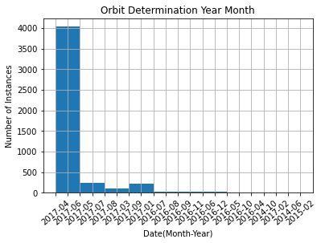

```python
df['Orbit Determination Year Month'] = df['Orbit Determination Date'].astype('datetime64').dt.strftime('%Y-%m')
df['Orbit Determination Year Month'].hist(xrot=40)
plt.ylabel('Number of Instances')
plt.xlabel('Date(Month-Year)')
plt.title('Orbit Determination Year Month')
```

```python
df.drop(['Orbit Determination Date','Orbit Determination Year Month'], axis=1, inplace=True)
```

### Pairplot for Remaining Features

It is a crowded plot with too many features but it may be helpful for a quick look. We can see there are some candidates for outliers but I will keep it simple and skip this for now.

Next plots are memory and time intensive so I will keep them as comments. (I ran it only once, normally I would not keep it in my analysis notebook)

```python
#sns.pairplot(df, kind='reg', diag_kind='kde')
```

Take a look on the large diameter (`Est Dia in KM(min)>3`) instances to see if there is anything to catch with eye.

```python
df[df['Est Dia in KM(min)']>3]
```

|  | Neo Reference ID | Absolute Magnitude | Est Dia in KM(min) | Relative Velocity km per sec | Miss Dist.(Astronomical) | Orbit ID | Orbit Uncertainity | Minimum Orbit Intersection | Jupiter Tisserand Invariant | Epoch Osculation | Eccentricity | Semi Major Axis | Inclination | Asc Node Longitude | Perihelion Distance | Perihelion Arg | Aphelion Dist | Perihelion Time | Mean Anomaly | Hazardous | Close Approach Year | Close Approach Month | Close Approach Day of Year |
| --- | --- | --- | --- | --- | --- | --- | --- | --- | --- | --- | --- | --- | --- | --- | --- | --- | --- | --- | --- | --- | --- | --- | --- |
| 297 | 2066146 | 14.50 | 3.346224 | 11.567926 | 0.431692 | 193 | 0 | 0.073339 | 7.289 | 2458000.5 | 0.483810 | 0.787100 | 5.412671 | 102.195356 | 0.406293 | 84.686655 | 1.167906 | 2.457885e+06 | 162.801143 | False | 1997 | 1 | 8 |
| 373 | 2001980 | 13.92 | 4.370740 | 12.844004 | 0.483878 | 412 | 0 | 0.245487 | 3.996 | 2458000.5 | 0.364815 | 1.709446 | 26.869362 | 246.574315 | 1.085815 | 115.485874 | 2.333076 | 2.458072e+06 | 328.595687 | False | 1997 | 7 | 189 |
| 673 | 2137170 | 14.60 | 3.195619 | 22.611651 | 0.244184 | 370 | 0 | 0.172442 | 6.986 | 2458000.5 | 0.462508 | 0.819136 | 25.661892 | 155.884875 | 0.440279 | 253.380850 | 1.197992 | 2.457976e+06 | 32.628497 | False | 1999 | 3 | 81 |
| 965 | 2004183 | 14.40 | 3.503926 | 21.198541 | 0.142653 | 350 | 0 | 0.028252 | 3.573 | 2458000.5 | 0.634350 | 1.982214 | 6.705068 | 294.895562 | 0.724797 | 236.340269 | 3.239631 | 2.458062e+06 | 338.280000 | True | 2000 | 12 | 357 |
| 1716 | 2000433 | 11.16 | 15.579552 | 4.412295 | 0.365567 | 611 | 0 | 0.150505 | 4.583 | 2458000.5 | 0.222589 | 1.457940 | 10.827591 | 304.322163 | 1.133419 | 178.816591 | 1.782461 | 2.457873e+06 | 71.280278 | False | 2005 | 3 | 67 |
| 2945 | 2004197 | 14.60 | 3.195619 | 30.760095 | 0.250829 | 106 | 0 | 0.098709 | 3.090 | 2458000.5 | 0.771579 | 2.296848 | 12.576624 | 7.184375 | 0.524649 | 122.404461 | 4.069047 | 2.458072e+06 | 339.880239 | False | 2010 | 10 | 288 |
| 4095 | 2004183 | 14.40 | 3.503926 | 29.715630 | 0.427696 | 350 | 0 | 0.028252 | 3.573 | 2458000.5 | 0.634350 | 1.982214 | 6.705068 | 294.895562 | 0.724797 | 236.340269 | 3.239631 | 2.458062e+06 | 338.280000 | True | 2014 | 12 | 342 |
| 4467 | 2001685 | 14.23 | 3.789265 | 16.889892 | 0.156550 | 358 | 0 | 0.050567 | 4.716 | 2454471.5 | 0.435874 | 1.367130 | 9.381529 | 274.341995 | 0.771233 | 127.072787 | 1.963026 | 2.454442e+06 | 18.419869 | False | 2016 | 1 | 22 |

```python
#dfcopy = df[df['Est Dia in KM(min)']<15]
#sns.pairplot(dfcopy, kind='reg', diag_kind='kde')
```

### Preprocessing the columns

There are some preprocessing steps. In normal circumstances, missing values needs to be imputed. Here, no need for this step.

Also, scaling or encoding would be other types of preprocessing steps that I will perform here.

```python
y = df.loc[:, df.columns == 'Hazardous'].astype(int)
X = df.loc[:, df.columns != 'Hazardous']
```

```python
numeric_features = X.select_dtypes(exclude="object").columns
categorical_features =  X.select_dtypes(include="object").columns
```

```python
numeric_transformer = Pipeline(steps=[
                                      ('scaler', StandardScaler())
                                    ])


categorical_transformer = Pipeline(steps=[
                                          ('onehot', OneHotEncoder(handle_unknown='ignore'))
                                         ])

preprocessor = ColumnTransformer(
                                 transformers=[
                                    ('num', numeric_transformer, numeric_features),
                                    ('cat', categorical_transformer, categorical_features)
                                ])
```

### Model Selection and Fitting:

```python
hazardous_perc = np.mean(df['Hazardous'])*100
print("%0.2f" %hazardous_perc, "% of the total astroids are hazardous in the data.")
```

```
16.11 % of the total astroids are hazardous in the data.
```

As we can see, only 16.1% of the asteroids are hazardous. Therefore, the data is unbalanced, and we need to be careful when we are evaluating the models. For example, if a model predicts everything as non-hazardous and missed all the hazardous asteroids. The accuracy will be 83.9% but it is equal to doing nothing! Therefore, we need to keep this in mind.

### Split the Data into Training, Test, and Validation Sets

```python
X_trainvalid, X_test, y_trainvalid, y_test = train_test_split(X, y, train_size=0.8, random_state=13)
X_train, X_valid, y_train, y_valid = train_test_split(X_trainvalid, y_trainvalid,
                                                          train_size=0.75, random_state=13)
```

### Accuracy Measures

In this example, we have unbalanced data, we need to be careful on accuracy. Since, number of correct predicted labels may not mean model is predicting useful results. Therefore, we have to be careful and get use of other measures from confusion matrix such as precision, recall or f1 score. Since we need to be able to predict positive class (**Hazardous**) in this unbalanced data. Here the formulas for better remembering.

$$Recall = \frac{TP}{TP+FN}$$$$Precision = \frac{TP}{TP+FP}$$$$F_1 = \frac{2* Precision * Recall}{Precision * Recall} $$

```python
def get_scores(model,
                X_train, y_train,
                X_valid, y_valid,
                show = True
               ):
    """
    Returns train and validation error given a model
    train and validation X and y portions
    Parameters
    ----------
    model: sklearn classifier model
        The sklearn model
    X_train: numpy.ndarray
        The X part of the train set
    y_train: numpy.ndarray
        The y part of the train set
    X_valid: numpy.ndarray
        The X part of the validation set
    y_valid: numpy.ndarray
        The y part of the validation set
    Returns
    -------
        train_err: float
        test_err: float
    """
    #y_pred = model.predict(X_valid)
    #auc = roc_auc_score(y_valid, y_pred)
    train_err = (1-model.score(X_train, y_train))
    valid_err = (1-model.score(X_valid, y_valid))

    if show:
        print("Training error:   %.2f" % train_err)
        print("Validation error: %.2f" % valid_err)
     #   print("ROC-Area Under Curve: %.2f" % auc )
        print('\n')
    return train_err, valid_err  # ,auc
```

```python
def display_confusion_matrix_classification_report(model, X_valid, y_valid,
                                                   labels=['Non hazardous', 'Hazardous']):
    """
    Displays confusion matrix and classification report.

    Arguments
    ---------
    model -- sklearn classifier model
        The sklearn model
    X_valid -- numpy.ndarray
        The X part of the validation set
    y_valid -- numpy.ndarray
        The y part of the validation set

    Keyword arguments:
    -----------
    labels -- list (default = ['Non fraud', 'Fraud'])
        The labels shown in the confusion matrix
    Returns
    -------
        None
    """
    ### Display confusion matrix
    disp = plot_confusion_matrix(model, X_valid, y_valid,
                                 display_labels=labels,
                                 cmap=plt.cm.Blues,
                                 values_format = 'd')
    disp.ax_.set_title('Confusion matrix for the dataset')

    ### Print classification report
    print(classification_report(y_valid, model.predict(X_valid)))
```

#### Dummy Model for Baseline

It will be useful to compare real classifiers.

For more info, [sklearn documentation](https://scikit-learn.org/stable/modules/generated/sklearn.dummy.DummyClassifier.html).

```python
# Lets create an empty dictionary to store all the results
results_dict = {}
```

```python
numeric_transformer = Pipeline(steps=[
                                    # ('imputer', SimpleImputer(strategy='median')),
                                      ('scaler', StandardScaler())
                                    ])


categorical_transformer = Pipeline(steps=[
                                          #('imputer', SimpleImputer(strategy='constant',
                                          #                          fill_value='missing')),
                                          ('onehot', OneHotEncoder(handle_unknown='ignore'))
                                         ])

preprocessor = ColumnTransformer(
                                 transformers=[
                                    ('num', numeric_transformer, numeric_features),
                                    ('cat', categorical_transformer, categorical_features)
                                ])
```

```python
print('Fitting baseline model: ')
dummy = DummyClassifier()

clf = Pipeline(steps=[('preprocessor', preprocessor),
                      ('classifier', dummy)])

t = time.time()
clf.fit(X_train, y_train)
t_fit = time.time()
tr_err, valid_err = get_scores(clf, X_train, y_train, X_valid, y_valid)
cross_val = cross_val_score(clf, X_train, y_train, cv=5)
y_pred = clf.predict(X_valid)
#auc= roc_auc_score(y_valid, y_pred)
f1_sc = f1_score(y_valid, y_pred)
t_predict = time.time()

time_to_fit = t_fit - t
time_to_predict = t_predict - t_fit


results_dict['dummy'] = [round(tr_err,3), "%0.2f (+/- %0.2f)" %(cross_val.mean(), cross_val.std() * 2), round(valid_err,3), round(f1_sc,3), round(time_to_fit,4), round(time_to_predict,4)]
```

```
Fitting baseline model:
Training error:   0.27
Validation error: 0.27
```

## Classifiers to Evaluate:

```python
models = {
          'decision tree': DecisionTreeClassifier(),
          'kNN': KNeighborsClassifier(),
          'logistic regression': LogisticRegression(),
          'RBF SVM' : SVC(),
          'random forest' : RandomForestClassifier(),
          'xgboost' : XGBClassifier(),
          'lgbm': LGBMClassifier()
         }

for model_name, model in models.items():
    t = time.time()
    #print(model_name, ":")
    clf = Pipeline(steps=[('preprocessor', preprocessor),
                          ('classifier', model)])

    clf.fit(X_train, y_train)
    tr_err, valid_err = get_scores(clf, X_train, y_train,
                                   X_valid, y_valid, show = False)
    cross_val = cross_val_score(clf, X_train, y_train, cv=5)
    t_fit = time.time()
    y_pred = clf.predict(X_valid)
    #auc= roc_auc_score(y_valid, y_pred)
    f1_sc = f1_score(y_valid, y_pred)
    t_predict = time.time()

    time_to_fit = t_fit - t
    time_to_predict = t_predict - t_fit

    results_dict[model_name] = [round(tr_err,3),"%0.2f (+/- %0.2f)" % (cross_val.mean(), cross_val.std() * 2), round(valid_err,3), round(f1_sc,3), round(time_to_fit,4), round(time_to_predict,4)]
    #print("Elapsed time: %.1f s" % elapsed_time)
```

```python
results_df = pd.DataFrame(results_dict).T
results_df.columns = ["Train error","Training CV Accuracy",  "Validation error", "F1 Score on Validation", "Fit Time in sec", "Predict Time in sec"]
results_df
```

|  | Train error | Training CV Accuracy | Validation error | F1 Score on Validation | Fit Time in sec | Predict Time in sec |
| --- | --- | --- | --- | --- | --- | --- |
| dummy | 0.268 | 0.75 (+/- 0.04) | 0.27 | 0.142 | 0.0163 | 0.1235 |
| decision tree | 0 | 0.99 (+/- 0.01) | 0.007 | 0.977 | 0.1899 | 0.0066 |
| kNN | 0.067 | 0.89 (+/- 0.04) | 0.112 | 0.601 | 1.3504 | 0.199 |
| logistic regression | 0.035 | 0.95 (+/- 0.02) | 0.042 | 0.867 | 0.3319 | 0.0063 |
| RBF SVM | 0.024 | 0.94 (+/- 0.02) | 0.053 | 0.823 | 1.0063 | 0.0434 |
| random forest | 0 | 0.99 (+/- 0.01) | 0.009 | 0.974 | 2.8599 | 0.0227 |
| xgboost | 0 | 0.99 (+/- 0.00) | 0.004 | 0.987 | 0.7252 | 0.0158 |
| lgbm | 0 | 0.99 (+/- 0.00) | 0.005 | 0.984 | 0.8425 | 0.0092 |

- SVM and kNN are slow models. So, it is best to eleminate them. Random Forest is also slow to fit and it is overfitted.
- Decision Tree, Random Forest and boosted models(xgboost and lgbm) seems overfitted. Training errors are 0. We can apply hyperparameter optimization.

### Hyperparameter optimization on Selected Model (Logistic Regression)

```python
# Hyperparameter optimization

clf = Pipeline(steps=[('preprocessor', preprocessor),
                      ('classifier', LogisticRegression())])

### We can also choose optimal class_weight ratio using grid search.
weights = np.linspace(0.05, 0.95, 20)

param_grid = {
    'classifier__C': [0.01, 0.1, 1.0, 10, 100],
    #'classifier__penalty': ['l1', 'l2', 'elasticnet', 'none'],
    'classifier__class_weight': [{0: x, 1: 1.0-x} for x in weights]
}

grid_search = GridSearchCV(clf,
                           param_grid=param_grid,
                           scoring='f1',
                           cv=10)
grid_search.fit(X_trainvalid, y_trainvalid)

print(("best logistic regression from grid search (F1 Score): %.3f"
       % grid_search.score(X_valid, y_valid)))
```

```
best logistic regression from grid search (F1 Score): 0.888
```

```python
print("Best parameters : %s" % grid_search.best_params_)
```

```
Best parameters : {'classifier__C': 1.0, 'classifier__class_weight': {0: 0.47631578947368414, 1: 0.5236842105263159}}
```

```
              precision    recall  f1-score   support

           0       0.98      0.98      0.98       785
           1       0.89      0.88      0.89       153

    accuracy                           0.96       938
   macro avg       0.94      0.93      0.93       938
weighted avg       0.96      0.96      0.96       938
```

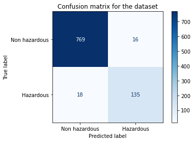

```python
display_confusion_matrix_classification_report(grid_search, X_valid, y_valid,
                                                   labels=['Non hazardous', 'Hazardous'])
```

Validation scores of 0.89 precision and 0.88 recall on hazardous class seems reasonably well. I will continue to use this Logistic Regression model for predicting unseen test data.

### Final Results on the test data:

```
              precision    recall  f1-score   support

           0       0.96      0.97      0.96       777
           1       0.83      0.82      0.83       161

    accuracy                           0.94       938
   macro avg       0.90      0.89      0.89       938
weighted avg       0.94      0.94      0.94       938
```

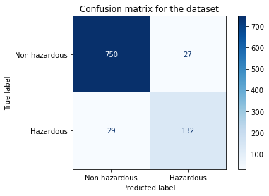

```python
display_confusion_matrix_classification_report(grid_search, X_test, y_test,
                                                   labels=['Non hazardous', 'Hazardous'])
```

If we want to increase the precision of classifying hazardous asteroids, it will cost a reduction in recall which means we will have more *non-hazardous* to be misidentified as *hazardous*. In the case of NASA, if we have more asteroids predicted as hazardous, it may increase the cost of tracking those asteroids and other studies. However, it will give peace of mind since a missed hazardous asteroid may result in massive natural destruction.

## Improvements and/or Other Approaches

Since we have unbalanced data, we could also perform:

- Undersampling: It is mainly undersampling the "non-hazardous" class to get balanced data and fit model on this.
- Oversampling: It is oversampling the minority class("hazardous"). There are different techniques for oversampling. One is random oversampling weith replacement. Another model is SMOTE (Synthetic Minority Over-sampling Technique). SMOTE creates "synthetic" instances instead of oversampling with replacement.

Here, I have selected Logistic Regression since it is fast and interpretable model. Boosted models with hyperparameter optimization will tends to give better results. This type of models can be another way to go.

Last but not least, making the analysis reproducible by automating some processes would be beneficial for future similar works. For the sake of simplicity, I keep all the code and analysis in a single JupyterNotebook. For the best practices, my next step would be breakdown down the code into scripts.